# RMSC5102 2020S A Question on Inverse Transform

LEUNG Man Fung, Heman

# Question

Why do we need to use cdf for inverse transform? Why can’t we use pdf?

# Answer

Let $v=f(x)$ be a general pdf and $w=F(x)=\int_{-\infty}^{x} f(t) dt$ be its cdf. Assume their inverse both exists, then we have $x=f^{-1}(v)$ and $x=F^{-1}(w)$.

To generate the random variable $X$ from the above relationship, we need to generate random $V$ or $W$ so as to put them into the inverse equation, i.e. $X=f^{-1}(V)$ or $X=F^{-1}(W)$.

In other words, we need to know how to generate random $V$ or $W$. The problem of using pdf for inverse transform is that we do not know what is the distribution of $V$ in general.

However, for cdf, $W \sim \textrm{Unif}(0,1)$ according to the [probability integral transform](https://en.wikipedia.org/wiki/Probability_integral_transform). As we know how to generate $\textrm{Unif}(0,1)$, we use cdf for inverse transform.

As our focus is on the simulation aspect, I am not going through the theory but rather illustrate with the example of epxonential distribution with pdf $f(x)=2e^{-2x},\ x>0$:
Note that the cdf is
$$\begin{aligned}
F(x) &= \int_0^x 2e^{-2t} dt \\
&= \left[ -e^{-2t} \right]_0^x \\
&= 1-e^{-2x}.
\end{aligned}$$
Let $V=f(X)=2e^{-2X}$ and $W=F(X)=1-e^{-2X}$. Then $X=-\frac{1}{2} ln(\frac{1}{2} V)$ and $X=-\frac{1}{2} ln(1-W)$. We use histograms to visualize their distributions:

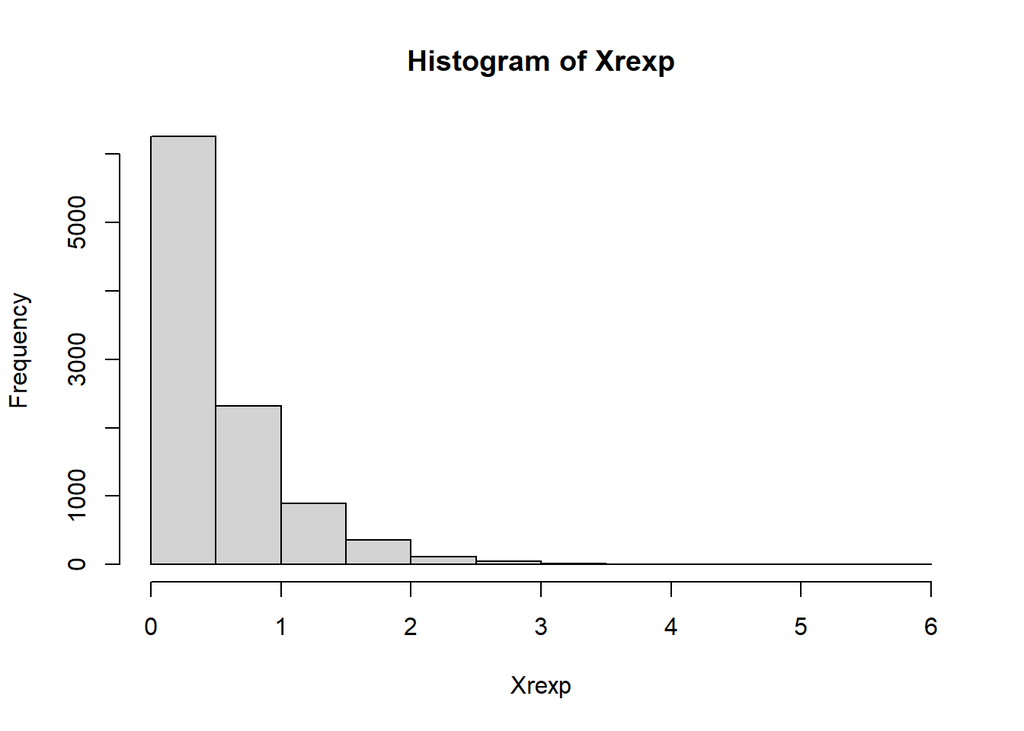

```r
Xrexp = rexp(10000,2) #use rexp function to generate
hist(Xrexp)
```

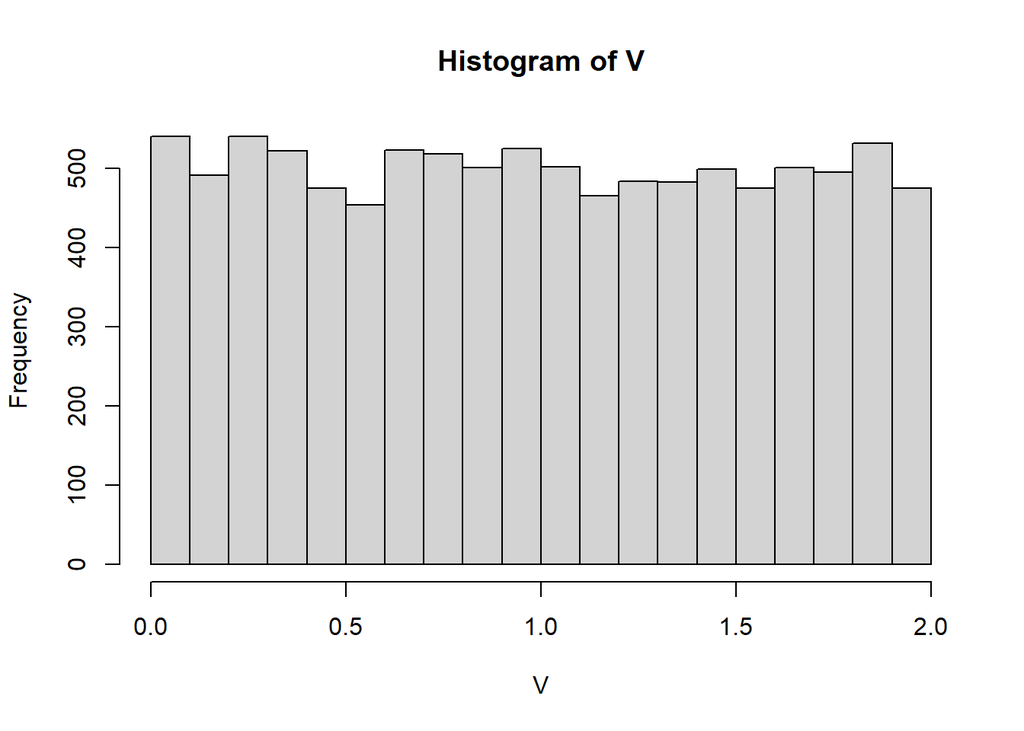

```r
V = 2*exp(-2*Xrexp)
hist(V) #plot shows not U(0,1). It is U(0,2) for this case
```

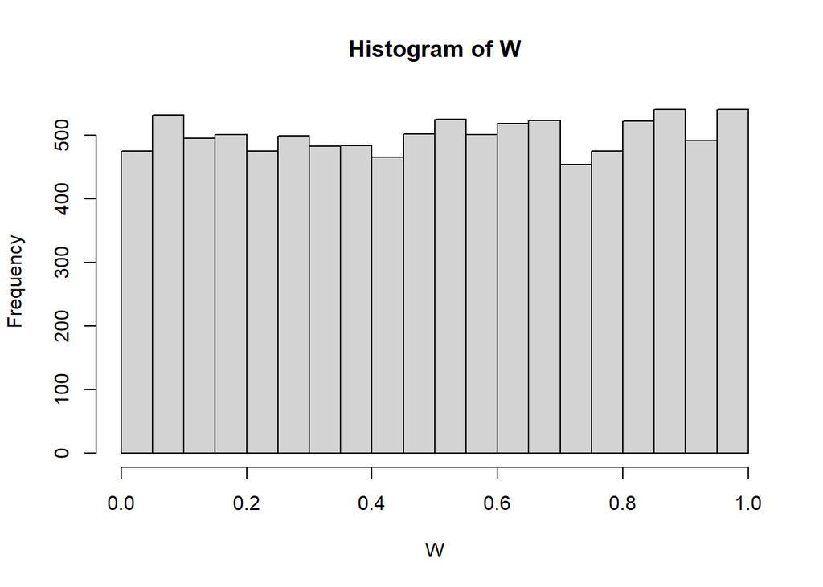

```r
W = 1-exp(-2*Xrexp)
hist(W) #plot shows close to U(0,1)
```

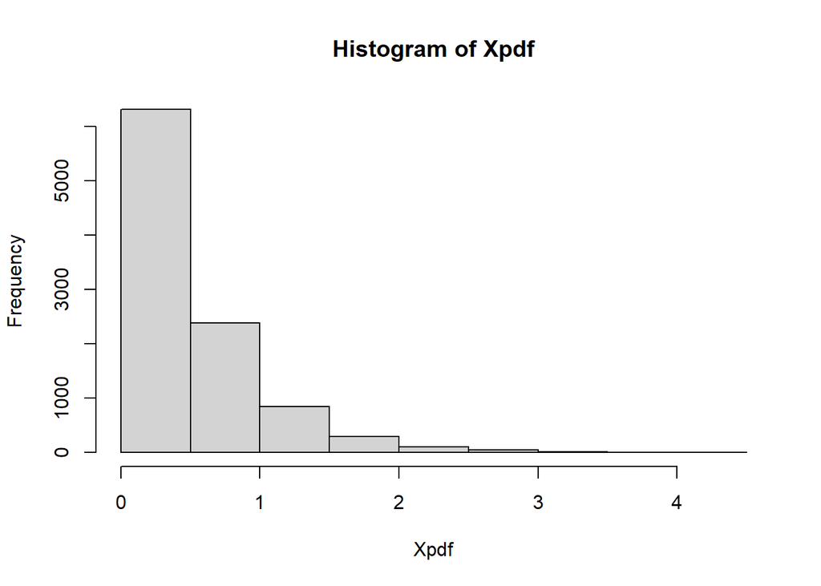

```r
# If we know V is U(0,2), we may try to use the pdf relation
V = runif(10000,0,2)
Xpdf = -0.5*log(0.5*V)
hist(Xpdf)
```

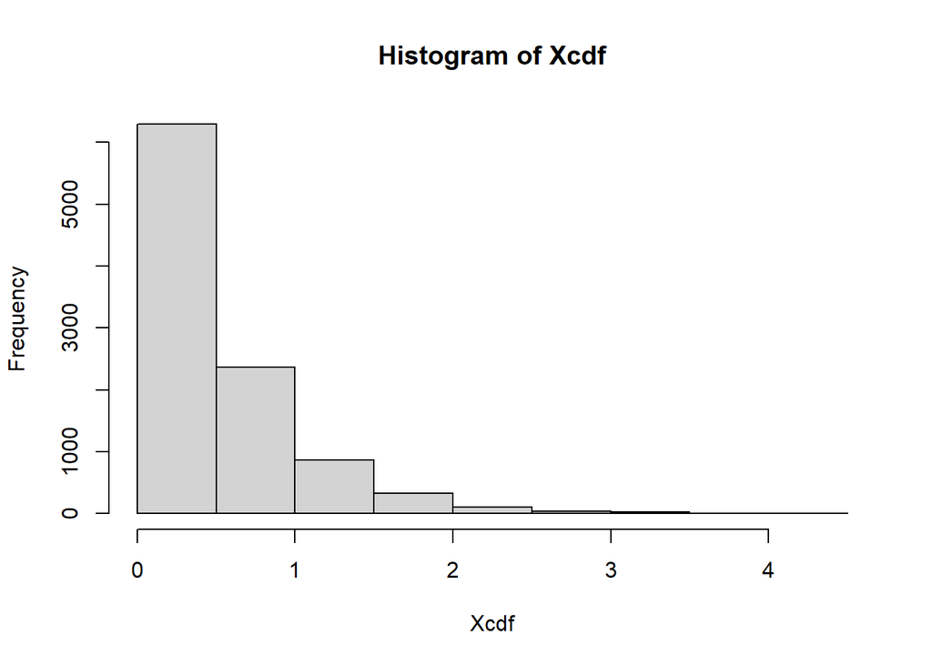

```r
# However we don't know V in general. So we use W~U(0,1) and cdf
W = runif(10000,0,1)
Xcdf = -0.5*log(1-W)
hist(Xcdf)
```